# Introduction

The goals of this analysis is to train, predict, evaluate, and SHAP BPNet models.

We will be training second-pass models including: ATAC residual model to learn accessibility grammar on:

- genome-wide
- 50/50 split accessible regions
- accessible regions only

# Computational setup

```python
%load_ext autoreload
%autoreload 2
%reload_ext autoreload

import warnings
warnings.filterwarnings("ignore")
from tensorflow.python.util import deprecation
deprecation._PRINT_DEPRECATION_WARNINGS = False

#Packages
import os
import sys
import keras
import pyBigWig
import json
import pandas as pd
import numpy as np
import keras.backend as K
from keras.models import load_model
from tqdm import tqdm

import plotnine
from plotnine import *

# Settings

## Working options
working_dir = f'/n/projects/mw2098/publications/2024_weilert_acc/code/2_analysis/'
os.chdir(working_dir)
pd.set_option('display.max_columns', 100)
figure_path = 'figures/3b_train_alternate_combined'
bpreveal_path = '/n/projects/mw2098/publications/2024_weilert_acc/public/software/bpreveal_404/'
python_path = '/home/mw2098/anaconda3/envs/bpreveal_404/bin/python'

## Custom functions
sys.path.insert(0, f'scripts/py/functions')
from metrics import compute_auprc
from functional import one_hot_encode_sequences, one_hot_encode_sequence, one_hot_decode_sequence, shuffle_seqs, logitsToProfile, insert_motif
from perturb import generate_random_seq
from motifs import extract_seqs_from_df, resize_coordinates

sys.path.insert(0, f'{bpreveal_path}/src')
import losses

output_profiles_path = 'tsv/insilico/marginalizations/motifs/all_alternate_showcase_profiles.tsv.gz'

## Filesystem commands
!mkdir -p \
    json \
    bed/bpreveal \
    input \
    models \
    preds \
    scripts/modeling \
    tsv \
    shap \
    npz \
    {figure_path}

!mkdir {figure_path}
```

[output not shown]

```
mkdir: cannot create directory ‘figures/3b_train_alternate_combined’: File exists
```

## Custom functions

The following function takes a list of str commands and generates a SLURM batch job with parameter allocations. This is mostly specific to Stowers computational resources, would recommend reworking the job submissions to match your own institutional setup if reproducing.

```python
def generate_slurm_array(cmds, output_file, simultaneous_jobs = 3, gpu = True, mem = 200):
    total_jobs = len(cmds)
    if gpu:
        gpu_fill = '#SBATCH --partition=gpu\n#SBATCH --gres=gpu:1\n#SBATCH --cpus-per-task=10'
    else:
        gpu_fill = '#SBATCH --cpus-per-task=10'
    array_header = ['#!/usr/bin/bash',
                  '#SBATCH --job-name bpnet_training',
                  '#SBATCH --output=slurm_%j.log',
                  f'#SBATCH --array=1-{total_jobs}%{simultaneous_jobs}',
                  f'#SBATCH --mem={mem}gb',
                  '#SBATCH --time=72:00:00',
                  gpu_fill,
                  'source /home/mw2098/.bashrc',
                  'conda deactivate',
                  'conda activate bpreveal_404',
                  'ml bedtools',
                  f'cd {working_dir}']
    # array_cmds = array_header
    for i,cmd in enumerate(cmds):
        array_cmd = ["if [[ ${{SLURM_ARRAY_TASK_ID}} == {0:d} ]] ; then\n".format(i+1),
                    "    {0:s}\n".format(cmd),
                    "fi\n\n"]
        array_header = array_header + array_cmd

    with open(output_file, mode='wt') as slurm:
        slurm.write('\n'.join(array_header))
        slurm.write('\n')
```

# Set up static modeling parameters

Here are the variables that will remain static throughout the optimization process.

```python
# Default model architecture
output_length = 1000
max_jitter = 100
batch_size = 64
learning_rate = 0.004 #BPReveal is adaptive, so this learning rate doesn't need optimizing.
early_stopping_patience = 8
reverse_complement = True
seed = 2346
trials = 256

#Annotations
genome = '../0_setup/fa/mm10.fa'
test_chroms = ['chr1', 'chr8', 'chr17']
val_chroms = ['chr2', 'chr3', 'chr9']
train_chroms = ['chr4', 'chr5', 'chr6', 'chr7', 'chr10', 'chr11', 'chr12', 'chr13',
                'chr14', 'chr15', 'chr16', 'chr18', 'chr19', 'chrX']
profile_metrics_of_interest = ['mnll', 'jsd']
counts_metrics_of_interest = ['counts-pearson', 'counts-spearman']
model_suffix = ['_residual.model', '_combined.model']

"""
Optimized architectures based on previous model training.
"""

train_settings_dict = {
    'bias_atac' : { #Generic Tn5 bias model
        'n_dil_layers' : 4,
        'conv1_kernel_size' : 21,
        'profile_kernel_size' : 75,
        'filters' : 128,
        'counts_loss_weight' : 10,
        'output_length': 1000,
    },
    'residual_atac' : { #Generic binding model
        'n_dil_layers' : 8,
        'conv1_kernel_size' : 7,
        'profile_kernel_size' : 7,
        'filters' : 128,
        'output_length': 1000,
        'counts_loss_weight' : 100
    }
}


#Calculate associate input lengths
input_length_dict = {}
for k,v in train_settings_dict.items():
    proxy_length = !{python_path} {bpreveal_path}/src/lengthCalc.py \
        --output-len {v['output_length']} \
        --n-dil-layers {v['n_dil_layers']} \
        --conv1-kernel-size {v['conv1_kernel_size']} \
        --profile-kernel-size {v['profile_kernel_size']}
    input_length_dict[k] = int(proxy_length[0])
input_length_dict
```

```
{'bias_atac': 1154, 'residual_atac': 2032}
```

```python
#Second-pass models to train
modeling_design_dict = {

    'atac_wt_across_genome': {
        'regions': {'mm10_genome': 'bed/mm10_genome_across_sliding_windows.bed'},
        'cov': {'atac': {'cutsite': 'bw/mesc_native_atac_cutsites_combined.bw'}},
        'bias_model_prefix': 'atac_wt', 'bias_settings_name': 'bias_atac', 'use_bias_counts': False,
        'train_settings_name': 'residual_atac'
    },
    'atac_wt_across_split': {
        'regions': {'mm10_genome': 'bed/mm10_acc_and_nonacc_split.bed'},
        'cov': {'atac': {'cutsite': 'bw/mesc_native_atac_cutsites_combined.bw'}},
        'bias_model_prefix': 'atac_wt', 'bias_settings_name': 'bias_atac', 'use_bias_counts': False,
        'train_settings_name': 'residual_atac'
    },
    'atac_wt_across_acc': {
        'regions': {'acc': 'narrowpeak/mesc_atac_peaks.narrowPeak'},
        'cov': {'atac': {'cutsite': 'bw/mesc_native_atac_cutsites_combined.bw'}},
        'bias_model_prefix': 'atac_wt', 'bias_settings_name': 'bias_atac', 'use_bias_counts': False,
        'train_settings_name': 'residual_atac'
    }

}
```

## Modify `modeling_cov_dict`

Create .json configurations for the different steps for BPReveal training.

```python
#Prepare .bw configurations. Remember, order matters here.
modeling_cov_dict = {}
for k,v in modeling_design_dict.items():
    bw_dict = {}
    if type(v['cov'])==str:
        bw_dict['prepare_bed_inputs'] = [{'bigwig-names': [v['cov']], 'max-quantile': 1, 'min-counts': 1}]
        bw_dict['prepare_train_inputs'] = [{'bigwig-files': [v['cov']], 'revcomp-task-order': 'auto'}]
    else:
        bw_dict['prepare_bed_inputs'] = [{'bigwig-names': list(v2.values()), 'max-quantile': 1, 'min-counts': 1} for v2 in v['cov'].values()]
        bw_dict['prepare_train_inputs'] = [{'bigwig-files': list(v2.values()), 'revcomp-task-order': 'auto'} for v2 in v['cov'].values()]
    modeling_cov_dict[k] = bw_dict
modeling_cov_dict.keys()
```

```
dict_keys(['atac_wt_across_genome', 'atac_wt_across_split', 'atac_wt_across_acc'])
```

## Prepare 3-fold region datasets

Define different chromosome folds for training.

```python
chromosome_folds_dict = {
    'fold1': {'train' : train_chroms,
              'val' : val_chroms,
              'test' : test_chroms},
    'fold2': {'train' : ['chr1', 'chr2', 'chr6', 'chr7', 'chr8', 'chr9', 'chr11', 'chr12',
                       'chr13', 'chr14', 'chr15','chr17', 'chr18', 'chr19'],
              'val' : ['chr3', 'chr5', 'chr16'],
              'test' : ['chr4', 'chr10', 'chrX']},
    'fold3': {'train' : ['chr2', 'chr3', 'chr6', 'chr8','chr9', 'chr10', 'chr11', 'chr12',
                       'chr15', 'chr16','chr17', 'chr18', 'chr19', 'chrX'],
              'val' : ['chr1', 'chr7', 'chr13'],
              'test' : ['chr4', 'chr5', 'chr14']}
}
```

# Train, predict, assess and SHAP final models

After optimization, we have architectures that are well-suited for our different types of models and training sets. Thus, we can train each model set over three different folds of chromosomes to ensure that models are stable and consistently returning the same sequence grammar.

## Define random sequences

```python
#Calculate associate input lengths
for k,v in train_settings_dict.items():
    proxy_length = !{python_path} {bpreveal_path}/src/lengthCalc.py \
        --output-len {v['output_length']} \
        --n-dil-layers {v['n_dil_layers']} \
        --conv1-kernel-size {v['conv1_kernel_size']} \
        --profile-kernel-size {v['profile_kernel_size']}
    input_length_dict[k] = int(proxy_length[0])
input_length_dict
```

```
{'bias_atac': 1154, 'residual_atac': 2032}
```

```python
for k,v in input_length_dict.items():
    random_seqs_path = f'npz/random_seqs_seed_{seed}_input_{v}_trials_{trials}_array.npz'
    seqs = [np.random.choice(['A', 'C','G', 'T'], v) for i in range(trials)]
    seqs_1he = one_hot_encode_sequences(seqs)
    np.savez(random_seqs_path, seqs_1he = seqs_1he)
```

## Prepare training datasets

First, write the .json files required to generate training datasets.

```python
#Loop through different input_lengths based on the different model requirements to generate data.
for model_name,model_bws in modeling_cov_dict.items():
    for fold_name,fold_chroms in chromosome_folds_dict.items():
        fold_prefix = model_name + '_' + str(fold_name)
        input_length = input_length_dict[modeling_design_dict[model_name]['train_settings_name']]
        output_length = train_settings_dict[modeling_design_dict[model_name]['train_settings_name']]['output_length']
        max_jitter = int(output_length*.2)

        #Consolidate into a .json-readable dictionary
        prepare_bed_regions_dict = {'heads': model_bws['prepare_bed_inputs'],
                                    'splits': {"test-chroms": fold_chroms['test'],
                                               "val-chroms": fold_chroms['val'],
                                               "train-chroms": fold_chroms['train'],
                                               "regions": list(modeling_design_dict[model_name]['regions'].values())},
                                    'genome': f'{genome}',
                                    'write-counts-to': f'bed/bpreveal/{fold_prefix}_all.stats',
                                    'output-length': output_length,
                                    'input-length': input_length,
                                    'max-jitter': max_jitter,
                                    'output-prefix': f'bed/bpreveal/{fold_prefix}',
                                    'resize-mode': 'center',
                                    'remove-overlaps': False,
                                    'verbosity': 'INFO'} #Switch this to DEBUG if you are missing regions
        prepare_bed_regions_json = json.dumps(prepare_bed_regions_dict, indent=4)
        bed_json_file = f'json/prepareBedPeaks_{fold_prefix}.json'
        with open(bed_json_file, 'w') as outfile:
            outfile.write(prepare_bed_regions_json)

        # Prepare input training data
        prepare_input_train_dict = {'genome': genome,
                            'input-length': input_length,
                            'output-length': output_length,
                            'max-jitter': max_jitter,
                            'regions': f'bed/bpreveal/{fold_prefix}_train.bed',
                            'output-h5': f'input/{fold_prefix}_train.h5',
                            'heads': model_bws['prepare_train_inputs'],
                            'reverse-complement': reverse_complement,
                            'verbosity': 'DEBUG'}
        prepare_input_train_json = json.dumps(prepare_input_train_dict, indent=4)
        train_json_file = f'json/prepareInputTrain_{fold_prefix}.json'
        with open(train_json_file, 'w') as outfile:
            outfile.write(prepare_input_train_json)

        # Prepare validation training data
        prepare_input_valid_dict = {'genome': genome,
                    'input-length': input_length,
                    'output-length': output_length,
                    'max-jitter': max_jitter,
                    'regions': f'bed/bpreveal/{fold_prefix}_val.bed',
                    'output-h5': f'input/{fold_prefix}_val.h5',
                    'heads': model_bws['prepare_train_inputs'],
                    'reverse-complement': reverse_complement,
                    'verbosity': 'DEBUG'}
        prepare_input_valid_json = json.dumps(prepare_input_valid_dict, indent=4)
        valid_json_file = f'json/prepareInputValid_{fold_prefix}.json'
        with open(valid_json_file, 'w') as outfile:
            outfile.write(prepare_input_valid_json)
```

Next, generate SLURM jobs to generate the .h5 and .bed files required for training/validation datasets.

```python
array_cmds = []
for model_name,model_bws in modeling_cov_dict.items():
    for fold_name,fold_chroms in chromosome_folds_dict.items():
        fold_prefix = model_name + '_' + str(fold_name)

        prepare_peaks_cmd = f'{python_path} {bpreveal_path}/src/prepareBed.py json/prepareBedPeaks_{fold_prefix}.json'
        prepare_train_cmd = f'{python_path} {bpreveal_path}/src/prepareTrainingData.py json/prepareInputTrain_{fold_prefix}.json'
        prepare_valid_cmd = f'{python_path} {bpreveal_path}/src/prepareTrainingData.py json/prepareInputValid_{fold_prefix}.json'

        #Write to a job array
        cmds_str = '\n'.join([prepare_peaks_cmd] + [prepare_train_cmd] + [prepare_valid_cmd])
        array_cmd = [cmds_str]
        array_cmds += array_cmd

generate_slurm_array(cmds = array_cmds, output_file = 'scripts/modeling/bpnet_residual_models_prepare_data.slurm',
                     simultaneous_jobs = 20, gpu = False)
print('sbatch scripts/modeling/bpnet_residual_models_prepare_data.slurm')
```

```
sbatch scripts/modeling/bpnet_residual_models_prepare_data.slurm
```

## Generate training scripts

Here, we will generate training .json configuration files and training scripts for the final training.

```python
array_cmds = []
for model_name,model_info in modeling_design_dict.items():
    tasks = list(model_info['cov'].keys())
    num_channels = len(list(model_info['cov'].values())[0].keys())
    train_settings = train_settings_dict[model_info['train_settings_name']]
    input_length = input_length_dict[model_info['train_settings_name']]

    for fold_name,fold_chroms in chromosome_folds_dict.items():

        fold_prefix = model_name + '_' + str(fold_name)

        #Determine bias/transform model information for training combined model.
        bias_prefix = os.path.basename(model_info['bias_model_prefix']) # + '_fold1'
        trans_prefix = bias_prefix + '_trans'

        #Set up training parameters for the base model
        train_dict = {'settings': {'output-prefix': f'models/{fold_prefix}',
                                   'transformation-model': {'transformation-model-file' : f'models/{trans_prefix}.model'},
                                   'epochs': 200,
                                   'early-stopping-patience': early_stopping_patience,
                                   'batch-size': batch_size,
                                   'learning-rate': learning_rate,
                                   'learning-rate-plateau-patience': 5,
                                   'max-jitter': max_jitter,
                                   'architecture': {'architecture-name': 'bpnet',
                                                    'input-length': input_length,
                                                    'output-length': output_length,
                                                    'model-name': fold_prefix,
                                                    'model-args': '',
                                                    'filters': train_settings['filters'],
                                                    'layers': train_settings['n_dil_layers'],
                                                    'input-filter-width': train_settings['conv1_kernel_size'],
                                                    'output-filter-width': train_settings['profile_kernel_size']}},
                      'heads': [{'num-tasks': num_channels,
                             'profile-loss-weight': 1,
                             'head-name': task,
                             'counts-loss-frac-target': .1,
                                     'counts-loss-weight': train_settings['counts_loss_weight'],
                                     'use-bias-counts': model_info['use_bias_counts']} for task in tasks],
                      'train-data': f'input/{fold_prefix}_train.h5',
                      'val-data': f'input/{fold_prefix}_val.h5',
                      'verbosity': 'WARNING'}

        train_json = json.dumps(train_dict, indent=4)
        train_json_file = f'json/trainCombinedModel_{fold_prefix}.json'
        with open(train_json_file, 'w') as outfile:
            outfile.write(train_json)

        #Set up prediction parameters, predict both combined and residual models
        model_predict = []
        for ms in model_suffix:
            ms_short = ms.replace('.model', '')
            pred_dict = {'settings': {'genome': genome,
                                      'output-h5': f'preds/{fold_prefix}{ms_short}.h5',
                                      'batch-size': 1, #batch_size,
                                      'heads': len(tasks),
                                      'architecture': {'model-file': f'models/{fold_prefix}{ms}',
                                                       'input-length': input_length,
                                                       'output-length': output_length}},
                         # 'bed-file': f'bed/bpreveal/{fold_prefix}_all.bed',
                         'bed-file':f'bed/bpreveal/atac_wt_fold1_all.bed',
                         'verbosity': 'DEBUG'}
            pred_json = json.dumps(pred_dict, indent=4)
            pred_json_file = f'json/predictPeaks_{fold_prefix}{ms_short}.json'
            with open(pred_json_file, 'w') as outfile:
                outfile.write(pred_json)

            cmd = f'{python_path} {bpreveal_path}/src/makePredictionsBed.py json/predictPeaks_{fold_prefix}{ms_short}.json'
            model_predict.append(cmd)

        #Set up training and prediction commands
        model_train = [f'{python_path} {bpreveal_path}/src/trainCombinedModel.py json/trainCombinedModel_{fold_prefix}.json']

        #Write to a job array
        # cmds_str = '\n'.join(model_train + model_predict)
        cmds_str = '\n'.join(model_predict)
        array_cmd = [cmds_str]
        array_cmds += array_cmd

generate_slurm_array(cmds = array_cmds, output_file = 'scripts/modeling/bpnet_residual_models_train.slurm', mem = 500)
print('sbatch scripts/modeling/bpnet_residual_models_train.slurm')
```

```
sbatch scripts/modeling/bpnet_residual_models_train.slurm
```

## Generate prediction .bw files and assess performance

Here, we will extract .bw coverage from the generated .h5 files and compare them to generated features in order to compute performance metrics

```python
array_cmds = []
for model_name,model_info in modeling_design_dict.items():
    for fold_name,fold_chroms in chromosome_folds_dict.items():
        fold_prefix = model_name + '_' + str(fold_name)
        for head_counter, (task, cov) in enumerate(model_info['cov'].items()):
            for channel_counter, (channel_name, channel) in enumerate(cov.items()):
                for ms in model_suffix:
                    ms_short = ms.replace('.model', '')
                    predict_cmd = f'{python_path} {bpreveal_path}/src/predictToBigwig.py \
                    --h5 preds/{fold_prefix}{ms_short}.h5 \
                    --bw preds/{fold_prefix}_{task}_{channel_name}{ms_short}.bw \
                    --head-id {head_counter} \
                    --task-id {channel_counter} --mode profile --verbose'

                    #Write to a job array
                    cmds_str = '\n'.join([predict_cmd])
                    array_cmd = [cmds_str]
                    array_cmds += array_cmd

generate_slurm_array(cmds = array_cmds, output_file = 'scripts/modeling/bpnet_residual_models_predict.slurm',
                     simultaneous_jobs = 20, gpu = False)
print('sbatch scripts/modeling/bpnet_residual_models_predict.slurm')
```

```
sbatch scripts/modeling/bpnet_residual_models_predict.slurm
```

## Compute performance metrics

Here, we will compute and compare performance metrics on the test set of chromosomes. We will assess the 50th percentile as the key feature of profile metrics as well as the overall total counts performance.

Note that we will also calculate the first-pass model performances across the same regions, such that we might fairly assess whether first- or the corralled second-pass combined models more rigorously learn the information.

First, calculate performance metrics and save in a .json file. NOTE: Here, we will be using the referenced model in 3_train_models.ipynb in order to do a fair comparison. Predicting no accessibility across the entire genome is NOT the same as learning thoughtful regulatory grammar.

```python
#Calculate residual modelshe e
array_cmds = []
for model_name,model_info in modeling_design_dict.items():
    for fold_name,fold_chroms in chromosome_folds_dict.items():
        fold_prefix = model_name + '_' + str(fold_name)
        for dataset in ['test','val','train']:
            peaks_path = f'bed/bpreveal/{fold_prefix}_{dataset}.bed'
            # peaks_path = f'bed/bpreveal/atac_wt_fold1_all.bed'

            for head_counter, (task, cov) in enumerate(model_info['cov'].items()):
                for channel_counter, (channel_name, channel) in enumerate(cov.items()):
                    for ms in model_suffix:
                        ms_short = ms.replace('.model', '')
                        reference_path = channel
                        preds_path = f'preds/{fold_prefix}_{task}_{channel_name}{ms_short}.bw'

                        #Compute correlations and profile metrics over quantiles
                        metrics_json_file = f'json/metrics_{fold_prefix}_{task}_{channel_name}{ms_short}_{dataset}.json'

                        metrics_cmd = f'{python_path} {bpreveal_path}/src/metrics.py \
                            --reference {reference_path} \
                            --pred {preds_path} \
                            --regions {peaks_path} \
                            --threads 70 --json-output --apply-abs --skip-zeroes | tee {metrics_json_file}'

                        #Write to a job array
                        cmds_str = '\n'.join([metrics_cmd])
                        array_cmd = [cmds_str]
                        array_cmds += array_cmd


generate_slurm_array(cmds = array_cmds, output_file = 'scripts/modeling/bpnet_residual_models_alternate_metrics.slurm',
                     simultaneous_jobs = 20, gpu = False)
print('sbatch scripts/modeling/bpnet_residual_models_alternate_metrics.slurm')
```

```
sbatch scripts/modeling/bpnet_residual_models_alternate_metrics.slurm
```

Next, consolidate performance metrics by the different parameters and save into a tidy .tsv file.

```python
metrics_df = pd.DataFrame()
for model_name,model_info in modeling_design_dict.items():
    for fold_name,fold_chroms in chromosome_folds_dict.items():
        fold_prefix = model_name + '_' + str(fold_name)

        #Determine bias/transform model information for training combined model.
        bias_prefix = os.path.basename(model_info['bias_model_prefix']) #+ '_' + str(fold_name)

        for dataset in ['test','val','train']:
            peaks_path = f'bed/bpreveal/{fold_prefix}_{dataset}.bed'
            for head_counter, (task, cov) in enumerate(model_info['cov'].items()):
                for channel_counter, (channel_name, channel) in enumerate(cov.items()):

                    for ms in model_suffix:
                        ms_short = ms.replace('.model', '')
                        reference_path = channel
                        preds_path = f'preds/{fold_prefix}_{task}_{channel_name}{ms_short}.bw'

                        #Compute correlations and profile metrics over quantiles
                        metrics_json_file = f'json/metrics_{fold_prefix}_{task}_{channel_name}{ms_short}_{dataset}.json'

                        with open(metrics_json_file) as f:
                            metrics_dict = json.load(f)

                        #Format into a tidy df
                        df = pd.DataFrame([os.path.basename(metrics_dict['predicted'])]).transpose()
                        df.columns = ['bw']
                        df[['model', 'bw']] = df['bw'].str.split('_fold', n=1, expand=True)
                        df[['fold', 'bw']] = df['bw'].str.split('_', n=1, expand=True)
                        df[['task', 'bw']] = df['bw'].str.split('_', n=1, expand=True)
                        df[['channel', 'bw']] = df['bw'].str.split('_', n=1, expand=True)
                        df[['filler', 'bw']] = df['bw'].str.split(f'.bw', n=1, expand=True)
                        df['dataset'] = dataset
                        df = df.drop('bw', axis = 1)
                        df[profile_metrics_of_interest] = [np.median(metrics_dict[metric]['quantiles']) for metric in profile_metrics_of_interest]
                        df[counts_metrics_of_interest] = [metrics_dict[metric] for metric in counts_metrics_of_interest]
                        metrics_df = pd.concat([metrics_df, df])

metrics_df.to_csv('tsv/performance_metrics_across_alternate_residual_train.tsv.gz', sep = '\t', index = False)
```

```python
metrics_df = pd.read_csv('tsv/performance_metrics_across_alternate_residual_train.tsv.gz', sep = '\t')
metrics_df[metrics_df.dataset=='test']
```

|  | model | fold | task | channel | filler | dataset | mnll | jsd | counts-pearson | counts-spearman |
| --- | --- | --- | --- | --- | --- | --- | --- | --- | --- | --- |
| 0 | atac_wt_across_genome | 1 | atac | cutsite | residual | test | -2399.587890 | 0.655205 | 0.484865 | 0.702688 |
| 1 | atac_wt_across_genome | 1 | atac | cutsite | combined | test | -1114.663109 | 0.504890 | 0.487358 | 0.713088 |
| 6 | atac_wt_across_genome | 2 | atac | cutsite | residual | test | -2148.206596 | 0.661792 | 0.085194 | 0.697255 |
| 7 | atac_wt_across_genome | 2 | atac | cutsite | combined | test | -1016.392451 | 0.512080 | 0.084932 | 0.709386 |
| 12 | atac_wt_across_genome | 3 | atac | cutsite | residual | test | -2091.010456 | 0.663330 | 0.435243 | 0.696680 |
| 13 | atac_wt_across_genome | 3 | atac | cutsite | combined | test | -1017.893804 | 0.517332 | 0.437986 | 0.707915 |
| 18 | atac_wt_across_split | 1 | atac | cutsite | residual | test | -2761.897365 | 0.557818 | 0.532936 | 0.556421 |
| 19 | atac_wt_across_split | 1 | atac | cutsite | combined | test | -1171.452293 | 0.331225 | 0.534063 | 0.558556 |
| 24 | atac_wt_across_split | 2 | atac | cutsite | residual | test | -2446.419089 | 0.562621 | 0.308566 | 0.544557 |
| 25 | atac_wt_across_split | 2 | atac | cutsite | combined | test | -1070.661370 | 0.335773 | 0.320401 | 0.548041 |
| 30 | atac_wt_across_split | 3 | atac | cutsite | residual | test | -2439.283876 | 0.560200 | 0.585529 | 0.550676 |
| 31 | atac_wt_across_split | 3 | atac | cutsite | combined | test | -1087.467248 | 0.338819 | 0.586633 | 0.553448 |
| 36 | atac_wt_across_acc | 1 | atac | cutsite | residual | test | -2758.564216 | 0.557302 | 0.530297 | 0.569381 |
| 37 | atac_wt_across_acc | 1 | atac | cutsite | combined | test | -1164.317064 | 0.330211 | 0.532047 | 0.571746 |
| 42 | atac_wt_across_acc | 2 | atac | cutsite | residual | test | -2415.428934 | 0.559508 | 0.563919 | 0.563281 |
| 43 | atac_wt_across_acc | 2 | atac | cutsite | combined | test | -1069.691787 | 0.335055 | 0.565591 | 0.566109 |
| 48 | atac_wt_across_acc | 3 | atac | cutsite | residual | test | -2456.990273 | 0.560480 | 0.566521 | 0.557321 |
| 49 | atac_wt_across_acc | 3 | atac | cutsite | combined | test | -1094.040591 | 0.340683 | 0.567908 | 0.559587 |

These performance metrics will be more directly compared in the next .Rmd.

## Calculate SHAP scores for all models

### Generate SHAP scores

Prepare SHAP regions. We will NOT be SHAPing over the entire genome.

```python
array_cmds = []

for model_name,model_info in modeling_design_dict.items():
    num_channels = len(list(model_info['cov'].values())[0].keys())
    input_length = input_length_dict[model_info['train_settings_name']]

    if 'genome' not in model_name:

        for fold_name,fold_chroms in chromosome_folds_dict.items():
            fold_prefix = model_name + '_' + str(fold_name)

            #Set up SHAP parameters for each task.
            shap_template_dict = {
                'genome': genome,
                'bed-file': f'bed/bpreveal/{fold_prefix}_all.bed',
                'input-length': input_length,
                'output-length': output_length,
                'num-shuffles': 20,
                'verbosity': 'DEBUG'
            }

            shap_dict = shap_template_dict.copy()
            shap_dict['model-file'] = f'models/{fold_prefix}_residual.model'
            for head_counter, (task, cov) in enumerate(model_info['cov'].items()):
                shap_dict['heads'] = len(list(model_info['cov'].keys()))
                shap_dict['head-id'] = head_counter
                shap_dict['profile-task-ids'] = list(range(num_channels))
                shap_dict['profile-h5'] = f'shap/{fold_prefix}_{task}_profile.h5'
                shap_dict['counts-h5'] = f'shap/{fold_prefix}_{task}_counts.h5'
                shap_json = json.dumps(shap_dict, indent=4)
                shap_json_file = f'json/shapFlat_{fold_prefix}_{task}.json'
                with open(shap_json_file, 'w') as outfile:
                    outfile.write(shap_json)

                #Set up the SHAP commands
                model_shap = [f'{python_path} {bpreveal_path}/src/interpretFlat.py json/shapFlat_{fold_prefix}_{task}.json']

                #Write to a job array
                cmds_str = '\n'.join(model_shap)
                array_cmd = [cmds_str]
                array_cmds += array_cmd

generate_slurm_array(cmds = array_cmds, output_file = 'scripts/modeling/bpnet_residual_models_shap.slurm')
print('sbatch scripts/modeling/bpnet_residual_models_shap.slurm')
```

```
sbatch scripts/modeling/bpnet_residual_models_shap.slurm
```

### Convert SHAP .h5 to .bw

```python
array_cmds = []
for model_name,model_info in modeling_design_dict.items():
    for fold_name,fold_chroms in chromosome_folds_dict.items():
        fold_prefix = model_name + '_' + str(fold_name)
        for task in list(model_info['cov'].keys()):

            counts_shap_cmd = f'{python_path} {bpreveal_path}/src/shapToBigwig.py \
            --h5 shap/{fold_prefix}_{task}_counts.h5 \
            --bw shap/{fold_prefix}_{task}_counts.bw \
            --verbose'

            profile_shap_cmd = f'{python_path} {bpreveal_path}/src/shapToBigwig.py \
            --h5 shap/{fold_prefix}_{task}_profile.h5 \
            --bw shap/{fold_prefix}_{task}_profile.bw \
            --verbose'

            #Write to a job array
            cmds_str = '\n'.join([profile_shap_cmd] + [counts_shap_cmd])
            array_cmd = [cmds_str]
            array_cmds += array_cmd

generate_slurm_array(cmds = array_cmds, output_file = 'scripts/modeling/bpnet_residual_models_shap_to_bw.slurm',
                     simultaneous_jobs = 20, gpu = False)
print('sbatch scripts/modeling/bpnet_residual_models_shap_to_bw.slurm')
```

```
sbatch scripts/modeling/bpnet_residual_models_shap_to_bw.slurm
```

## Calculate balanced SHAP scores for all models

Given the possibility that some models learn more important motifs than others, ensure that SHAP was performed across the same features

### Generate SHAP scores

```python
array_cmds = []

for model_name,model_info in modeling_design_dict.items():
    num_channels = len(list(model_info['cov'].values())[0].keys())
    input_length = input_length_dict[model_info['train_settings_name']]


    for fold_name,fold_chroms in chromosome_folds_dict.items():
        fold_prefix = model_name + '_' + str(fold_name)

        #Set up SHAP parameters for each task.
        shap_template_dict = {
            'genome': genome,
            'bed-file': f'bed/bpreveal/atac_wt_fold1_all.bed',
            'input-length': input_length,
            'output-length': output_length,
            'num-shuffles': 20,
            'verbosity': 'DEBUG'
        }

        shap_dict = shap_template_dict.copy()
        shap_dict['model-file'] = f'models/{fold_prefix}_residual.model'
        for head_counter, (task, cov) in enumerate(model_info['cov'].items()):
            shap_dict['heads'] = len(list(model_info['cov'].keys()))
            shap_dict['head-id'] = head_counter
            shap_dict['profile-task-ids'] = list(range(num_channels))
            shap_dict['profile-h5'] = f'shap/{fold_prefix}_{task}_profile_across_balanced.h5'
            shap_dict['counts-h5'] = f'shap/{fold_prefix}_{task}_counts_across_balanced.h5'
            shap_json = json.dumps(shap_dict, indent=4)
            shap_json_file = f'json/shapFlat_{fold_prefix}_{task}_across_balanced.json'
            with open(shap_json_file, 'w') as outfile:
                outfile.write(shap_json)

            #Set up the SHAP commands
            model_shap = [f'{python_path} {bpreveal_path}/src/interpretFlat.py json/shapFlat_{fold_prefix}_{task}_across_balanced.json']

            #Write to a job array
            cmds_str = '\n'.join(model_shap)
            array_cmd = [cmds_str]
            array_cmds += array_cmd

generate_slurm_array(cmds = array_cmds, output_file = 'scripts/modeling/bpnet_residual_models_shap_across_balanced.slurm')
print('sbatch scripts/modeling/bpnet_residual_models_shap_across_balanced.slurm')
```

```
sbatch scripts/modeling/bpnet_residual_models_shap_across_balanced.slurm
```

### Convert SHAP .h5 to .bw

```python
array_cmds = []
for model_name,model_info in modeling_design_dict.items():
    for fold_name,fold_chroms in chromosome_folds_dict.items():
        fold_prefix = model_name + '_' + str(fold_name)
        for task in list(model_info['cov'].keys()):

            counts_shap_cmd = f'{python_path} {bpreveal_path}/src/shapToBigwig.py \
            --h5 shap/{fold_prefix}_{task}_counts_across_balanced.h5 \
            --bw shap/{fold_prefix}_{task}_counts_across_balanced.bw \
            --verbose'

            profile_shap_cmd = f'{python_path} {bpreveal_path}/src/shapToBigwig.py \
            --h5 shap/{fold_prefix}_{task}_profile_across_balanced.h5 \
            --bw shap/{fold_prefix}_{task}_profile_across_balanced.bw \
            --verbose'

            #Write to a job array
            cmds_str = '\n'.join([profile_shap_cmd] + [counts_shap_cmd])
            array_cmd = [cmds_str]
            array_cmds += array_cmd

generate_slurm_array(cmds = array_cmds, output_file = 'scripts/modeling/bpnet_residual_models_shap_to_bw_across_balanced.slurm',
                     simultaneous_jobs = 20, gpu = False)
print('sbatch scripts/modeling/bpnet_residual_models_shap_to_bw_across_balanced.slurm')
```

```
sbatch scripts/modeling/bpnet_residual_models_shap_to_bw_across_balanced.slurm
```

# Select showcase motifs

We will also select motifs that occur sufficiently in the genome to have been learned.

```python
high_motifs_df = pd.DataFrame(
    [['ATTTGCATGACAATG', 'AACAATGGG', 'TGGGTGGGGCC', 'GCACAGCAGGG', 'GCAATCAA', 'ATTTGCATG', 'ATGGCGGC', 'TGGACA'],
     ['high','high','high','high','high', 'high', 'high', 'high'],
     ['Oct4-Sox2','Sox2','Klf4','Zic3','Nanog', 'Oct4', 'Yy1', 'Hic1']],

).transpose()
high_motifs_df.columns = ['seq', 'affinity', 'motif']

showcase_motifs_df = pd.concat([high_motifs_df]).reset_index(drop = True)
showcase_motifs_df
```

|  | seq | affinity | motif |
| --- | --- | --- | --- |
| 0 | ATTTGCATGACAATG | high | Oct4-Sox2 |
| 1 | AACAATGGG | high | Sox2 |
| 2 | TGGGTGGGGCC | high | Klf4 |
| 3 | GCACAGCAGGG | high | Zic3 |
| 4 | GCAATCAA | high | Nanog |
| 5 | ATTTGCATG | high | Oct4 |
| 6 | ATGGCGGC | high | Yy1 |
| 7 | TGGACA | high | Hic1 |

# Predict showcased motifs

Load the model and show what the profiles look like across these sequences.

## Predict motifs

```python
preds_df = pd.DataFrame()
for model_name,model_info in tqdm(modeling_design_dict.items()):
    K.clear_session()

    model_dir = f'models/{model_name}_fold1_residual.model'
    model = load_model(model_dir, custom_objects = {'multinomialNll' : losses.multinomialNll, 'reweightableMse': losses.dummyMse})
    null_seqs = np.load(random_seqs_path)['seqs_1he']
    tasks = list(model_info['cov'].keys())
    channels = 1

    #Predict null binding
    null_preds_raw_arr = model.predict(null_seqs, verbose = False)

    null_preds_avg_df = pd.DataFrame()
    for i,task in tqdm(enumerate(tasks)):

        #Convert logits and logcounts to human-readable ChIP-nexus profile with counts
        profile_by_task = []
        for j in range(trials):
            profile = logitsToProfile(logitsAcrossSingleRegion = null_preds_raw_arr[i][j],
                                      logCountsAcrossSingleRegion = null_preds_raw_arr[i + len(tasks)][j])
            profile_by_task.append(profile)

        #Average across trials
        null_pred_avg_arr = np.mean(np.array(profile_by_task), axis = 0)

        #Convert to tidy pd.df
        null_pred_avg_df = pd.DataFrame(null_pred_avg_arr, columns = list(range(channels)))
        null_pred_avg_df['position'] = list(range(null_pred_avg_df.shape[0]))
        null_pred_avg_df = null_pred_avg_df.melt(id_vars = 'position', var_name = 'channel', value_name = 'null_pred')
        null_pred_avg_df['task'] = task
        null_preds_avg_df = pd.concat([null_preds_avg_df, null_pred_avg_df])

    #Predict injected binding for marginalizations
    injected_preds_df = pd.DataFrame()
    for i,row in showcase_motifs_df.iterrows():

        #Inject motif into null sequences
        injected_seqs = []
        for k in range(trials):
            injected_seq = insert_motif(seq = one_hot_decode_sequence(null_seqs[k]),
                                        motif = row.seq,
                                        position = input_length//2)
            injected_seqs.append(injected_seq)
        injected_seqs_1he = one_hot_encode_sequences(injected_seqs)

        #Predict injected sequences
        injected_preds_raw_arr = model.predict(injected_seqs_1he, verbose = False)

        #Process injected predictions to tidy pd.df
        injected_preds_avg_df = pd.DataFrame()
        for k,task in enumerate(tasks):

            #Convert logits and logcounts to human-readable ChIP-nexus profile with counts
            profile_by_task = []
            for j in range(trials):
                profile = logitsToProfile(logitsAcrossSingleRegion = injected_preds_raw_arr[k][j],
                                          logCountsAcrossSingleRegion = injected_preds_raw_arr[k + len(tasks)][j])
                profile_by_task.append(profile)

            #Average across trials
            injected_pred_avg_arr = np.mean(np.array(profile_by_task), axis = 0)

            #Convert to tidy pd.df
            injected_pred_avg_df = pd.DataFrame(injected_pred_avg_arr, columns = list(range(channels)))
            injected_pred_avg_df['position'] = list(range(injected_pred_avg_df.shape[0]))
            injected_pred_avg_df = injected_pred_avg_df.melt(id_vars = 'position', var_name = 'channel', value_name = 'pred')
            injected_pred_avg_df['task'] = task
            injected_preds_avg_df = pd.concat([injected_preds_avg_df, injected_pred_avg_df])

        injected_preds_avg_df['motif'] = row.motif
        injected_preds_avg_df['affinity'] = row.affinity
        injected_preds_avg_df['seq'] = row.seq

        injected_preds_df = pd.concat([injected_preds_df, injected_preds_avg_df])
    injected_preds_df['model_name'] = model_name
    injected_preds_df = injected_preds_df.merge(null_preds_avg_df, how = 'left', on = ['position', 'channel', 'task'])
    preds_df = pd.concat([preds_df, injected_preds_df])
preds_df.head(n=10)
```

```
  0%|                                                                                                                                                   | 0/3 [00:00<?, ?it/s]
1it [00:00, 101.82it/s]
 33%|██████████████████████████████████████████████▎                                                                                            | 1/3 [00:27<00:54, 27.46s/it]
1it [00:00, 90.57it/s]
 67%|████████████████████████████████████████████████████████████████████████████████████████████▋                                              | 2/3 [00:53<00:26, 26.90s/it]
1it [00:00, 97.23it/s]
100%|███████████████████████████████████████████████████████████████████████████████████████████████████████████████████████████████████████████| 3/3 [01:20<00:00, 26.91s/it]
```

|  | position | channel | pred | task | motif | affinity | seq | model_name | null_pred |
| --- | --- | --- | --- | --- | --- | --- | --- | --- | --- |
| 0 | 0 | 0 | 1.394881 | atac | Oct4-Sox2 | high | ATTTGCATGACAATG | atac_wt_across_genome | 0.769723 |
| 1 | 1 | 0 | 1.381052 | atac | Oct4-Sox2 | high | ATTTGCATGACAATG | atac_wt_across_genome | 0.764986 |
| 2 | 2 | 0 | 1.390684 | atac | Oct4-Sox2 | high | ATTTGCATGACAATG | atac_wt_across_genome | 0.753613 |
| 3 | 3 | 0 | 1.329597 | atac | Oct4-Sox2 | high | ATTTGCATGACAATG | atac_wt_across_genome | 0.735172 |
| 4 | 4 | 0 | 1.390364 | atac | Oct4-Sox2 | high | ATTTGCATGACAATG | atac_wt_across_genome | 0.760538 |
| 5 | 5 | 0 | 1.377523 | atac | Oct4-Sox2 | high | ATTTGCATGACAATG | atac_wt_across_genome | 0.752377 |
| 6 | 6 | 0 | 1.368215 | atac | Oct4-Sox2 | high | ATTTGCATGACAATG | atac_wt_across_genome | 0.750987 |
| 7 | 7 | 0 | 1.403867 | atac | Oct4-Sox2 | high | ATTTGCATGACAATG | atac_wt_across_genome | 0.750027 |
| 8 | 8 | 0 | 1.376443 | atac | Oct4-Sox2 | high | ATTTGCATGACAATG | atac_wt_across_genome | 0.742904 |
| 9 | 9 | 0 | 1.352315 | atac | Oct4-Sox2 | high | ATTTGCATGACAATG | atac_wt_across_genome | 0.741917 |

## Plot showcased predictions

```python
preds_df['task'] = [row.task.capitalize() + ' pred.' for i, row in preds_df.iterrows()]
preds_df['motif'] = [row.motif + ' motif' for i, row in preds_df.iterrows()]
preds_df['stranded_pred'] = (preds_df['pred'] * -1).where(preds_df['channel']==1, preds_df['pred'])
preds_df['stranded_null_pred'] = (preds_df['null_pred'] * -1).where(preds_df['channel']==1, preds_df['null_pred'])
preds_df['label'] = preds_df['motif'].str.cat(preds_df['affinity'], sep='_').str.cat(preds_df['channel'].astype(str), sep='_')
preds_df.to_csv(output_profiles_path, sep = '\t', index = False)

preds_df.head(n=10)
```

|  | position | channel | pred | task | motif | affinity | seq | model_name | null_pred | stranded_pred | stranded_null_pred | label |
| --- | --- | --- | --- | --- | --- | --- | --- | --- | --- | --- | --- | --- |
| 0 | 0 | 0 | 1.394881 | Atac pred. | Oct4-Sox2 motif | high | ATTTGCATGACAATG | atac_wt_across_genome | 0.769723 | 1.394881 | 0.769723 | Oct4-Sox2 motif_high_0 |
| 1 | 1 | 0 | 1.381052 | Atac pred. | Oct4-Sox2 motif | high | ATTTGCATGACAATG | atac_wt_across_genome | 0.764986 | 1.381052 | 0.764986 | Oct4-Sox2 motif_high_0 |
| 2 | 2 | 0 | 1.390684 | Atac pred. | Oct4-Sox2 motif | high | ATTTGCATGACAATG | atac_wt_across_genome | 0.753613 | 1.390684 | 0.753613 | Oct4-Sox2 motif_high_0 |
| 3 | 3 | 0 | 1.329597 | Atac pred. | Oct4-Sox2 motif | high | ATTTGCATGACAATG | atac_wt_across_genome | 0.735172 | 1.329597 | 0.735172 | Oct4-Sox2 motif_high_0 |
| 4 | 4 | 0 | 1.390364 | Atac pred. | Oct4-Sox2 motif | high | ATTTGCATGACAATG | atac_wt_across_genome | 0.760538 | 1.390364 | 0.760538 | Oct4-Sox2 motif_high_0 |
| 5 | 5 | 0 | 1.377523 | Atac pred. | Oct4-Sox2 motif | high | ATTTGCATGACAATG | atac_wt_across_genome | 0.752377 | 1.377523 | 0.752377 | Oct4-Sox2 motif_high_0 |
| 6 | 6 | 0 | 1.368215 | Atac pred. | Oct4-Sox2 motif | high | ATTTGCATGACAATG | atac_wt_across_genome | 0.750987 | 1.368215 | 0.750987 | Oct4-Sox2 motif_high_0 |
| 7 | 7 | 0 | 1.403867 | Atac pred. | Oct4-Sox2 motif | high | ATTTGCATGACAATG | atac_wt_across_genome | 0.750027 | 1.403867 | 0.750027 | Oct4-Sox2 motif_high_0 |
| 8 | 8 | 0 | 1.376443 | Atac pred. | Oct4-Sox2 motif | high | ATTTGCATGACAATG | atac_wt_across_genome | 0.742904 | 1.376443 | 0.742904 | Oct4-Sox2 motif_high_0 |
| 9 | 9 | 0 | 1.352315 | Atac pred. | Oct4-Sox2 motif | high | ATTTGCATGACAATG | atac_wt_across_genome | 0.741917 | 1.352315 | 0.741917 | Oct4-Sox2 motif_high_0 |

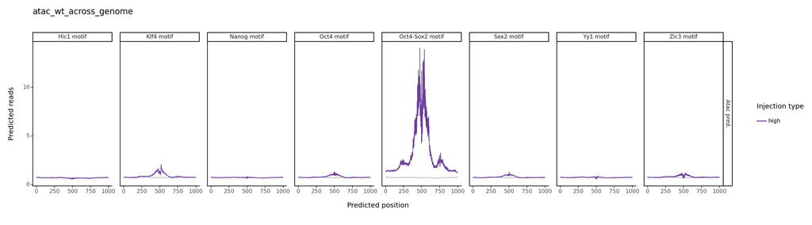

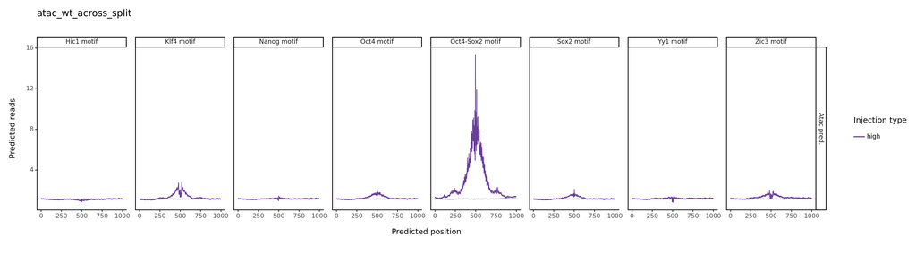

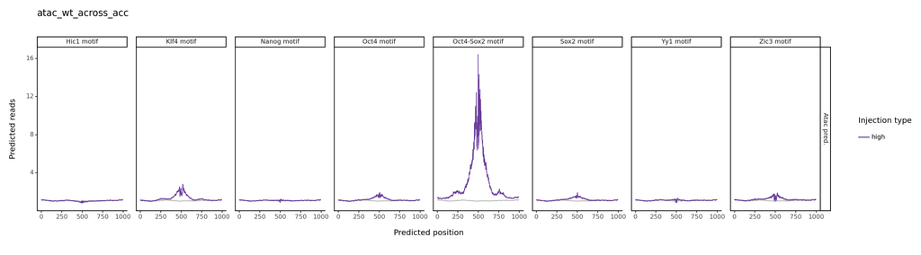

```python
for model_name,model_info in modeling_design_dict.items():
    plotnine.options.figure_size = (18, 5)

    p_df = preds_df[preds_df['model_name']==model_name]
    showcase_injections_plot = (ggplot()+
        geom_line(data = p_df,
                  mapping = aes(x = 'position', y = 'stranded_null_pred', group = 'channel'), color = 'gray', alpha = .5)+
        geom_line(data = p_df,
                  mapping = aes(x = 'position', y = 'stranded_pred', color = 'affinity', group = 'label'))+
        scale_x_continuous(name = 'Predicted position')+
        scale_y_continuous(name = 'Predicted reads')+
        scale_color_manual(name = 'Injection type', values = ['#6a3d9a', '#33a02c', '#1f78b4'])+
        facet_grid('task ~ motif', scales = 'free_y')+
        ggtitle(model_name)+
        theme_classic())

    if 'h' in model_name:
        showcase_injections_plot = (showcase_injections_plot + scale_y_continuous(name = 'Predicted reads', limits = (0, 65)))
        plotnine.options.figure_size = (18, 2.5)
    if 'atac' in model_name:
        plotnine.options.figure_size = (18, 2.5)

    showcase_injections_plot.save(f'{figure_path}/showcase_affinity_injections_{model_name}.png')
    showcase_injections_plot.save(f'{figure_path}/showcase_affinity_injections_{model_name}.pdf')
    print(showcase_injections_plot)
```